# Reproducible Research W2 Project 1

Khalid

7/3/2020

## Introduction

### It is now possible to collect a large amount of data about personal movement using activity monitoring devices such as a Fitbit, Nike Fuelband, or Jawbone Up.

The variables included in this dataset are:

- steps: Number of steps taking in a 5-minute interval (missing values are - coded as NA)
- date: The date on which the measurement was taken in YYYY-MM-DD format
- interval: Identifier for the 5-minute interval in which measurement was taken

# The work starts from Here

### The packagaes that I need

- dblyr
- ggplot2
- Hmisc data.table

```r
library(dplyr)
```

```r
library(ggplot2)
library(Hmisc)
library(data.table)
```

- Dataset: [Activity monitoring data](https://d396qusza40orc.cloudfront.net/repdata%2Fdata%2Factivity.zip)

### Unzip the folder and read it as CSV format

```r
unzip('repdata_data_activity.zip')
Activity <- read.csv('activity.csv', stringsAsFactors = F)
```

### Optional to change the date format

```r
Activity$date <- as.POSIXct(Activity$date, format = '%Y-%m-%d')
```

### Calculate the total number of steps taken per day

```r
Total_Steps <- group_by(Activity[complete.cases(Activity), ], date) %>%
    summarise(total = sum(steps, na.rm = T))
head(Total_Steps)
```

```
## # A tibble: 6 x 2
##   date                total
##   <dttm>              <int>
## 1 2012-10-02 00:00:00   126
## 2 2012-10-03 00:00:00 11352
## 3 2012-10-04 00:00:00 12116
## 4 2012-10-05 00:00:00 13294
## 5 2012-10-06 00:00:00 15420
## 6 2012-10-07 00:00:00 11015
```

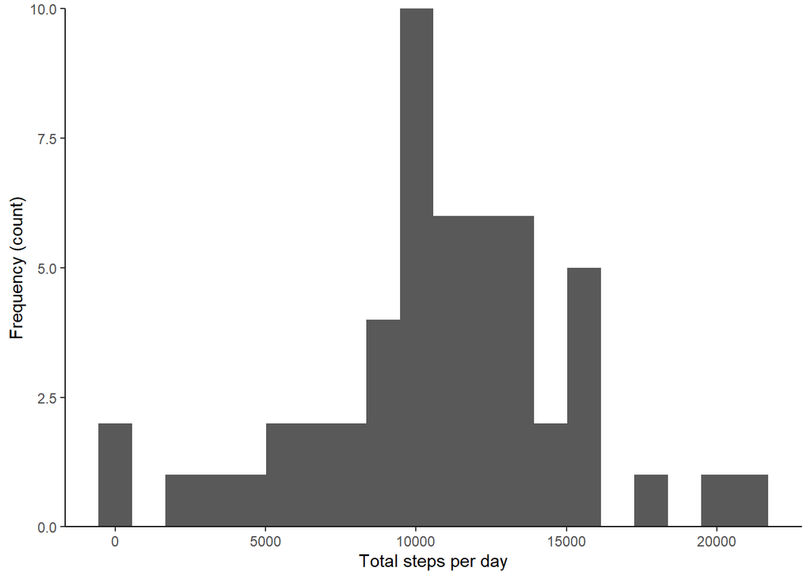

```r
ggplot(Total_Steps, aes(x = total)) + geom_histogram(bins = 20) +
    xlab('Total steps per day') +
    ylab('Frequency (count)') +
    scale_y_continuous(expand = c(0, 0)) + theme_classic()
```

### Calculate and report the **mean** and **median** total number of steps taken per day.

```r
cat('The Mean of the total number of steps taken per day is :', mean(Total_Steps$total))
```

```
## The Mean of the total number of steps taken per day is : 10766.19
```

```r
cat('Median of the total number of steps taken per day is:', median(Total_Steps$total))
```

```
## Median of the total number of steps taken per day is: 10765
```

### What is the average daily activity pattern?

- Make a time series plot (i.e. type = “l”) of the 5-minute interval (x-axis) and the average number of steps taken, averaged across all days (y-axis)

```r
interval_D <- group_by(Activity, interval) %>%
   summarise(mean = mean(steps, na.rm = T))
```

### Ploting the new data

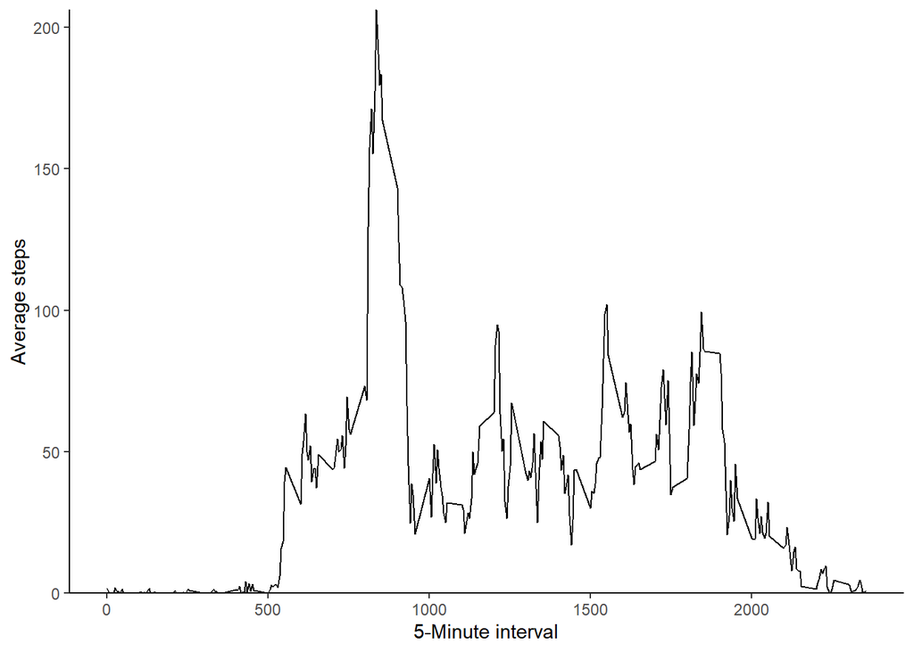

```r
ggplot(interval_D, aes(x = interval, y = mean)) +
  geom_line() +
  xlab('5-Minute interval') +
  ylab('Average steps') +
  scale_y_continuous(expand = c(0, 0)) + theme_classic()
```

- Which 5-minute interval, on average across all the days in the dataset, contains the maximum number of steps?

```r
cat('The 5- minute interval: ', interval_D[which.max(interval_D$mean), ]$interval, 'which contains the maximum mean number of steps is: ', interval_D[which.max(interval_D$mean), ]$mean)
```

```
## The 5- minute interval:  835 which contains the maximum mean number of steps is:  206.1698
```

### Imputing missing values

##### Note that there are a number of days/intervals where there are missing values (coded as NA). The presence of missing days may introduce bias into some calculations or summaries of the data.

### Calculate and report the total number of missing values in the dataset (i.e. the total number of rows with NAs)

```r
sum(is.na(Activity$steps))
```

```
## [1] 2304
```

```r
sum(is.na(Activity$date))
```

```
## [1] 0
```

```r
sum(is.na(Activity$interval))
```

```
## [1] 0
```

### display the result after summing.

```r
cat('There are', sum(is.na(Activity$steps)), 'NA "missing values" in the steps column!')
```

```
## There are 2304 NA "missing values" in the steps column!
```

### Devise a strategy for filling in all of the missing values in the dataset. The strategy does not need to be sophisticated. For example, you could use the mean/median for that day, or the mean for that 5-minute interval, etc.

```r
day_mean_Data <- group_by(Activity, date) %>% summarise(daily_Steps_Mean = mean(steps))
cat('Missing values for Daily Steps are:', sum(is.na(day_mean_Data$daily_Steps_Mean)))
```

```
## Missing values for Daily Steps are: 8
```

```r
table(is.na(interval_D$mean))
```

```
##
## FALSE
##   288
```

### imputing missing values using the 5-min interval mean with a function

```r
# mv = missing value,
mean_filling <- function(mv, n){
    imputedD <- c()
    for (i in 1:nrow(mv)) {
        if (is.na(mv[i, 'steps']) == T) {
            imputedD[i] <- n[n$interval == mv[i, 'interval'], ]$mean

        }else{
            imputedD[i] <- mv[i, 'steps']

        }

    }
    return(imputedD)

}
```

### Create a new dataset that is equal to the original dataset but with the missing data filled in.

```r
new_Activity <- Activity
new_Activity <- mutate(new_Activity, steps = mean_filling(new_Activity, interval_D))
```